# Homework 1

### 1.

#### (a) Dataset

```r
library(ggplot2)
salary <- read.csv("C:/Users/Sophie/Documents/Statistics/hw1/Salaries.csv")
dim(salary)
```

```
## [1] 148654     13
```

#### (b) Features

- Continuous features: BasePay, OvertimePay, OtherPay, Benefits, TotalPay, TotalPayBenefits,
- Categorical features: Id, EmployeeName, JobTitle, Year, Notes, Agency, Status

Sometimes the default types R choose doesn’t make sense, so I converted the types:

```r
set.seed(123)
index <- sample(1:nrow(salary), 2000)
salary2 <- salary[index,]
salary2$BasePay <- sapply(salary2$BasePay, as.numeric)
salary2$OvertimePay <- sapply(salary2$OvertimePay, as.numeric)
salary2$OtherPay <- sapply(salary2$OtherPay, as.numeric)
salary2$Benefits <- sapply(salary2$Benefits, as.numeric)
salary2$Id <- sapply(salary2$Id, factor)
salary2$Year <- sapply(salary2$Year, factor)
salary2$Notes <- sapply(salary2$Notes, as.factor)
```

```r
sapply(salary2, class)
```

```
##               Id     EmployeeName         JobTitle          BasePay
##         "factor"         "factor"         "factor"        "numeric"
##      OvertimePay         OtherPay         Benefits         TotalPay
##        "numeric"        "numeric"        "numeric"        "numeric"
## TotalPayBenefits             Year            Notes           Agency
##        "numeric"         "factor"         "factor"         "factor"
##           Status
##         "factor"
```

#### (c) Summaries

Use a subset of 2000 data points to summary.

```r
sapply(salary2, summary)
```

[output not shown]

[output cut: 182 more lines]

```
## $Year
## 2012 2014 2011 2013
##  508  504  484  504
##
## $Notes
## NA's
## 2000
##
## $Agency
## San Francisco
##          2000
##
## $Status
##        FT   PT
## 1496  295  209
```

#### (d) Plots

Use a subset of 2000 data points to plot.

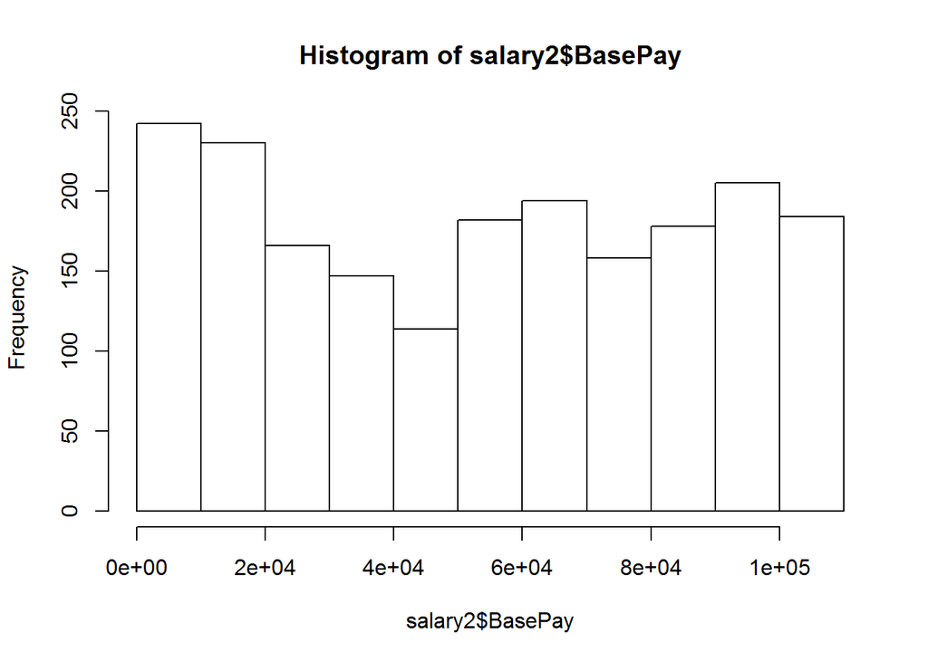

```r
hist(salary2$BasePay)
```

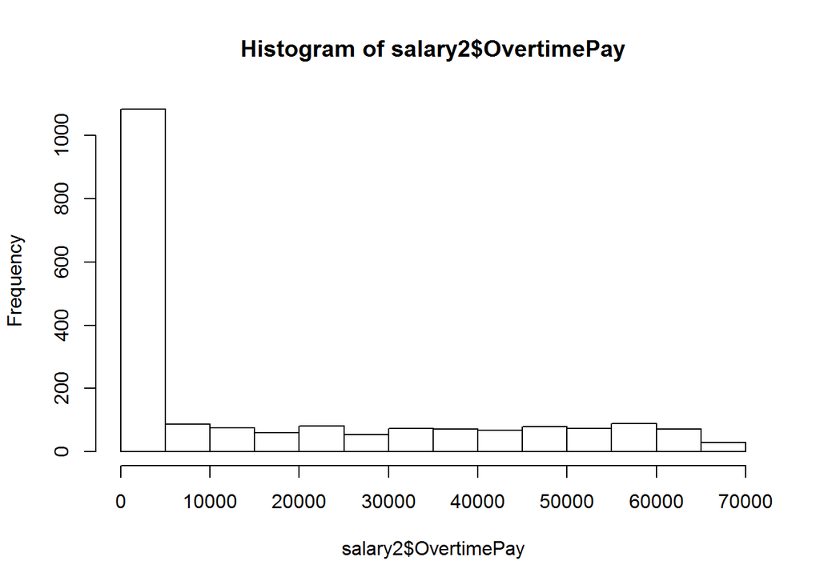

```r
hist(salary2$OvertimePay)
```

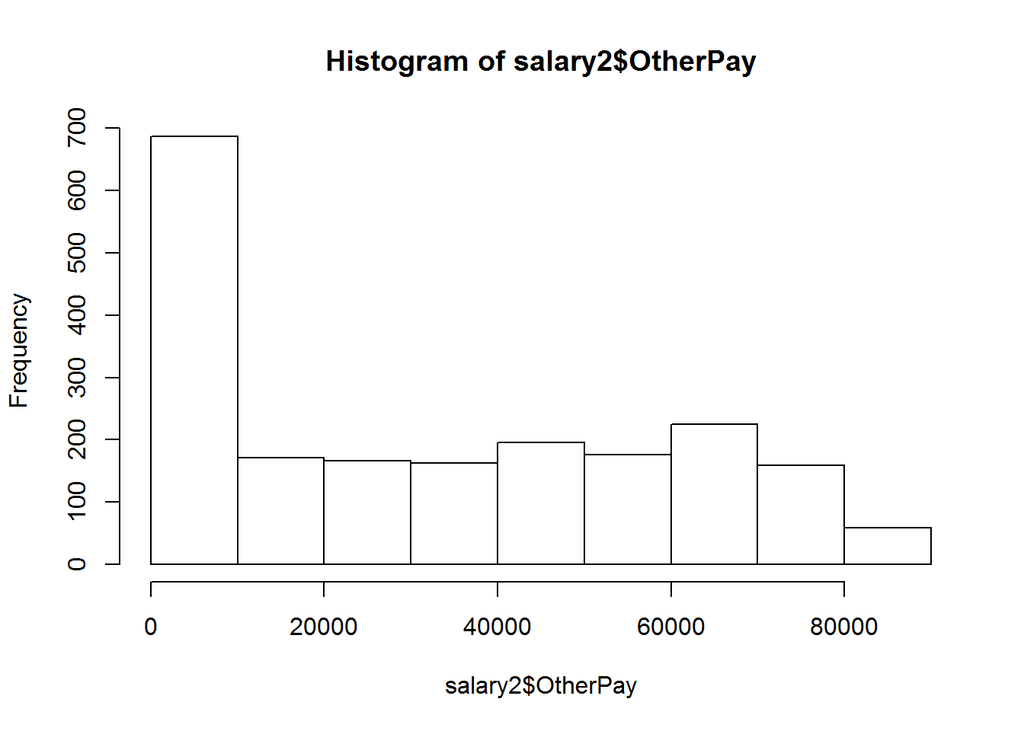

```r
hist(salary2$OtherPay)
```

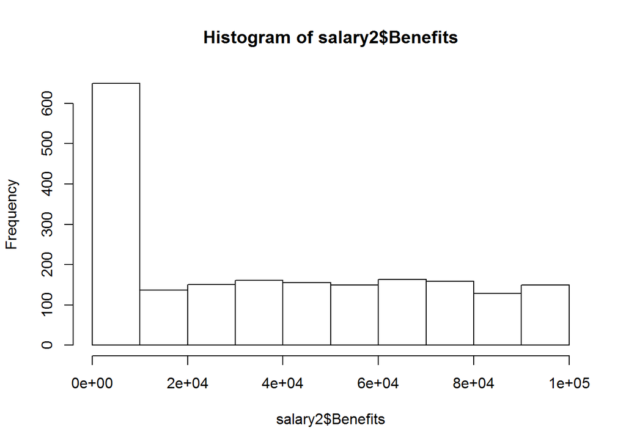

```r
hist(salary2$Benefits)
```

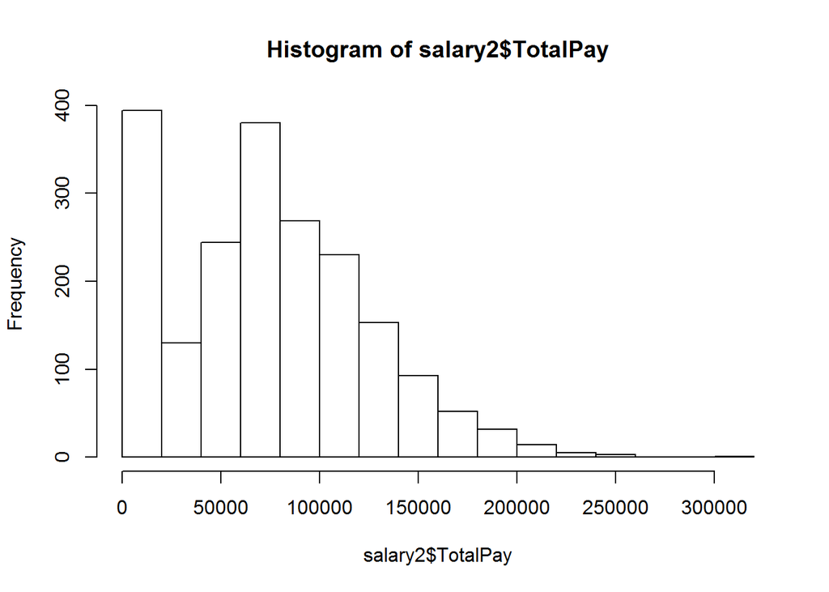

```r
hist(salary2$TotalPay)
```

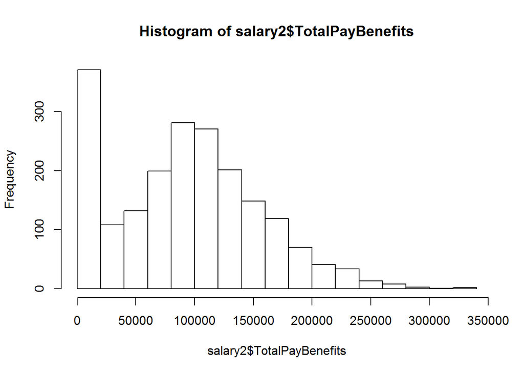

```r
hist(salary2$TotalPayBenefits)
```

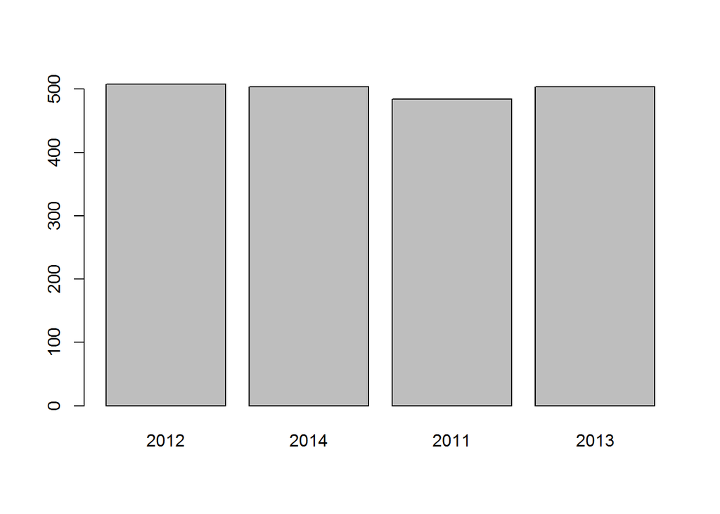

```r
plot(salary2$Year)
```

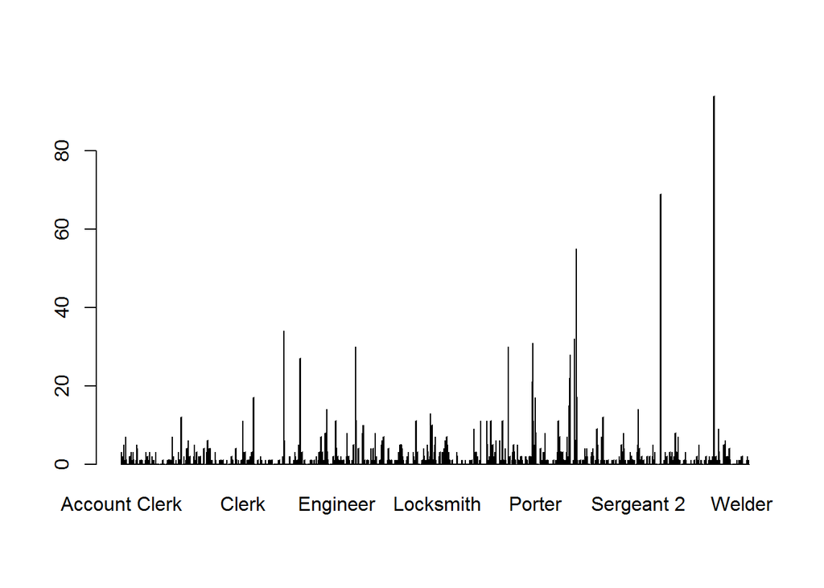

```r
plot(salary2$JobTitle)
```

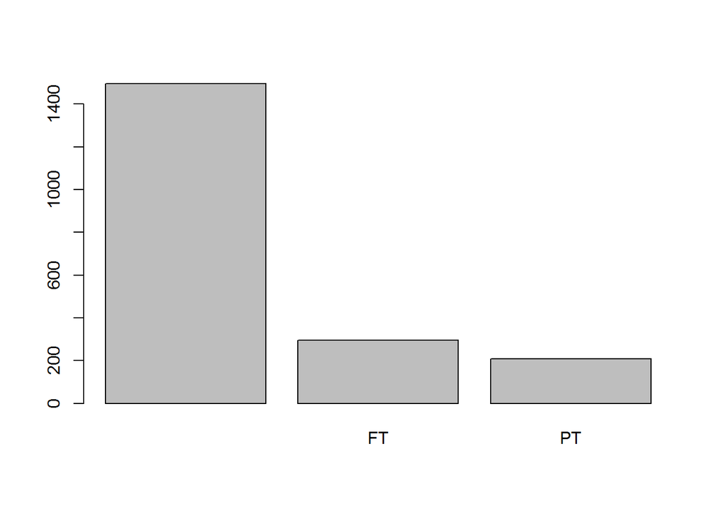

```r
plot(salary2$Status)
```

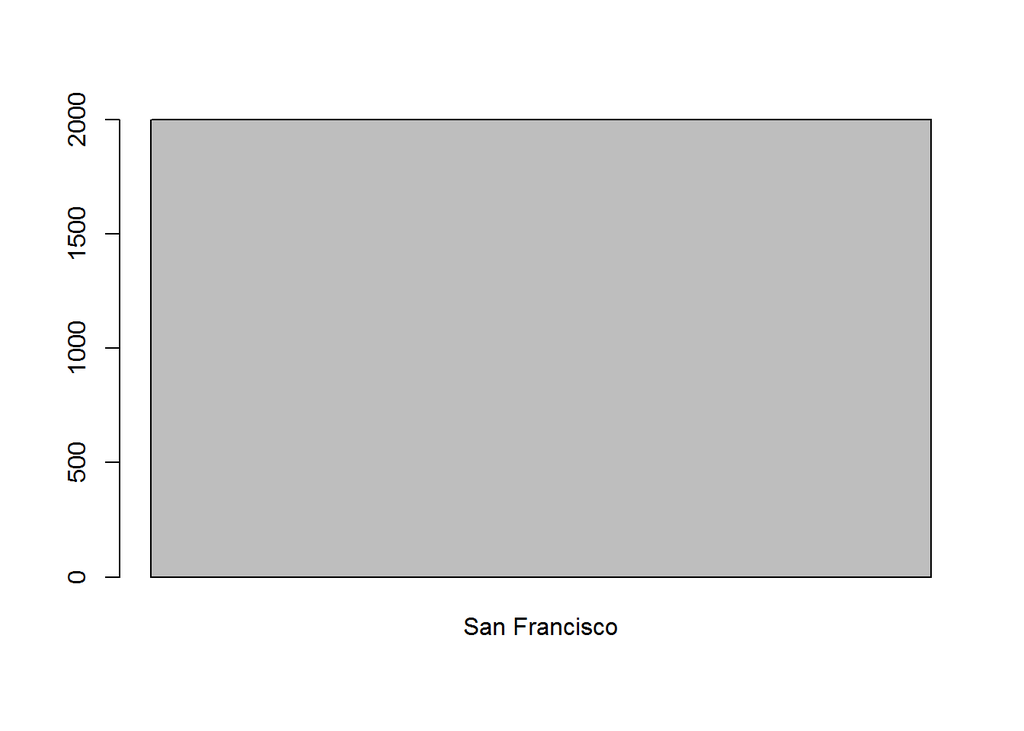

```r
plot(salary2$Agency)
```

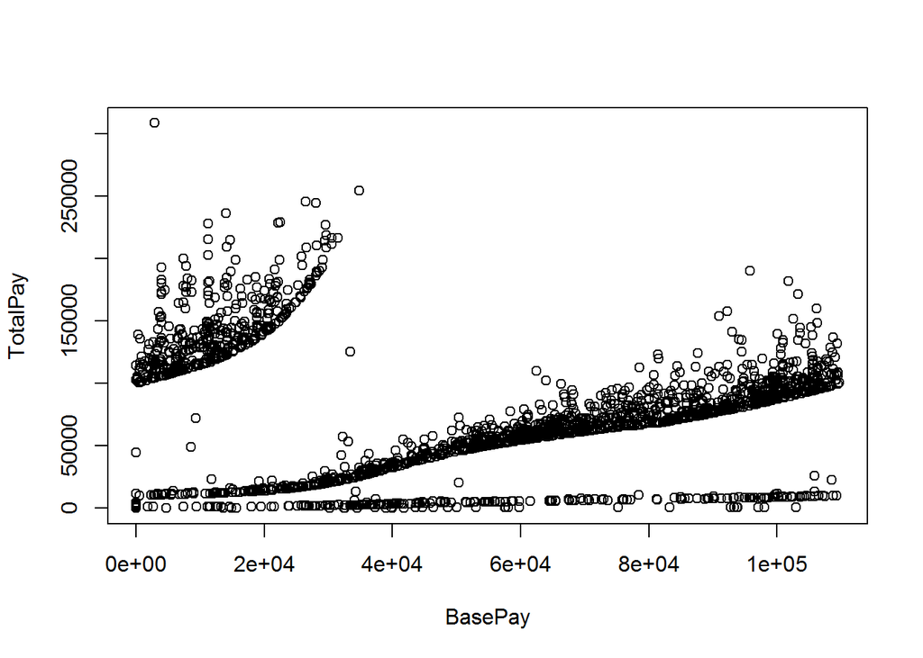

```r
plot(TotalPay ~ BasePay, data=salary2)
```

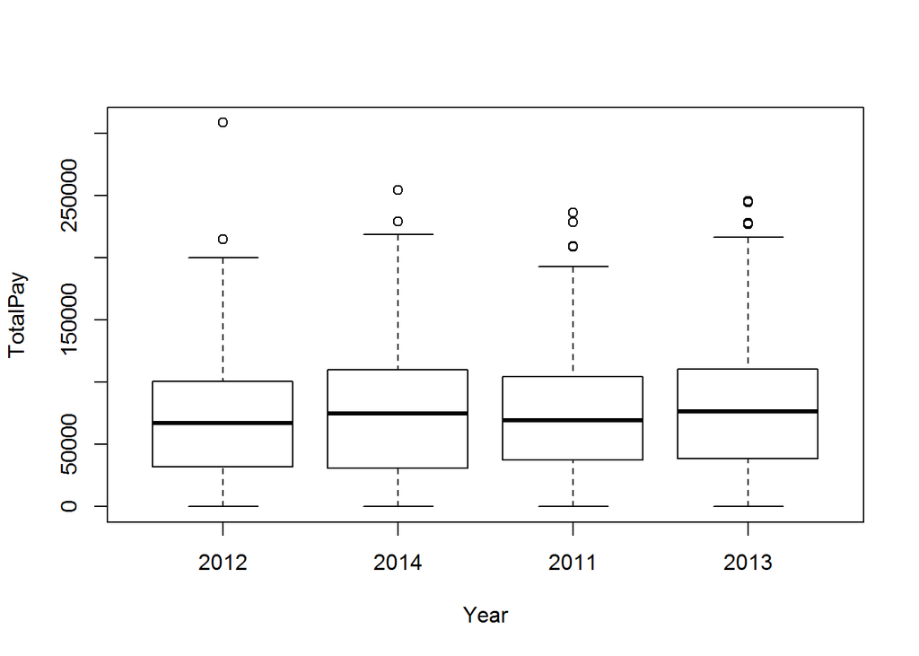

```r
plot(TotalPay ~ Year, data=salary2)
```

### 2.

#### (a)

For the normal histogram, price are divided into bins of size 2000.

- From 0 to 2000: 20 diamonds
- From 2000 to 4000: 9 diamonds
- From 4000 to 6000: 9 diamonds
- From 6000 to 8000: 4 diamonds
- From 8000 to 10000: 1 diamonds
- From 10000 to 12000: 3 diamonds
- From 12000 to 14000: 3 diamonds
- From 14000 to 16000: 1 diamonds

For the quantile histogram, price are divided into 4 quantile Since each quantile contains approximately the same number of data points, the area of each quantile is 1/4 = 0.25.

- Height of 1st quantile: 0.25/(1213-537)=0.00037
- Height of 2nd quantile: 0.25/(2831-1213)=0.000155
- Height of 3rd quantile: 0.25/(5725-2831)=0.000086
- Height of 4th quantile: 0.25/(14710-5725)=0.000028

#### (b)

For the normal histogram, the number of diamonds with price less than 4000 is 20+9=29.

For the quantile histogram, the proportion of diamonds with price less than 4000 is 0.25+0.25+0.25x(4000-2831)/(5725-2831)=0.60, the number is 0.6x50=30

The results of both histograms are about the same, if we accept some rounding errors in the computation.